# Final

## Predicting Incomes >$50,000 with logistic regression and recursive partitioning

*Mira and Kate*

## Part 1: Brief Intro to our Project and Dataset

-Response Variable: Income >50K, <50K

-13 predictors

```
+ Quantitative: education-num,  capital-gain, capital-loss, hours-per-week

+ Categorical: workclass, education, relationship, marital status , race, sex, native-country, occupation
```

- ~30,000 cases total, each representing and individual

Our data from Kaggle can be found here [https://www.kaggle.com/uciml/adult-census-income] and it is data collected by the 1994 US Census on people over the age of 16, but under the age of 100. The task given was to predict whether a person would make over $50,000 a year. Since no real application was provided, we imagined how this data could be very useful for a company that wanted to do targeted advertising for low-income and high-income consumers.

First we imported our data, then we looked at the relative of the importance of different variables using the importance values from a random forest (note: native.country has too many levels for us to include it, so we filtered it out…in the future we could remove some cases from less numerous countries)

```r
mod_Everything <- randomForest(income ~.-native.country, data = census, importance = TRUE)
importance(mod_Everything, type=1)
```

```
##                MeanDecreaseAccuracy
## age                       89.196866
## workclass                 47.996086
## fnlwgt                     2.349982
## education                 56.589424
## education.num             38.628604
## marital.status            44.817730
## occupation               101.290980
## relationship              37.263624
## race                      16.971303
## sex                       39.310176
## capital.gain             179.646654
## capital.loss              96.146961
## hours.per.week            57.643281
```

## Part 2: Logistic Regression

**Submitting this as separate .Rmd file**

## Part 3: Recusive Partitioning

**‘Tuning’ the tree by modifying the Gini Coefficient threshold**

The first approach we used was to create a tree to create a model to classify our data as well as to more easily be able to visualize the classifications and important variables our model was basing it off. Trees are easy to build and intuitive to look at, and an example we started with based off the importance values from running a preliminary randomForest model would be…

```r
mod4<-rpart(income~capital.gain+capital.loss+occupation+age,data=c_train)
```

But we needed a way to determine how many model terms to include… One approach would be to try to make many trees where we manually choose different terms to include, but the rpart() function actually has a paramter, cp, that automatically sets a certain threshold for how ‘useful’ a term must be for it to be added. After looking through the R Documentation, we learned this ‘cp’ was actally the Gini Coefficient we studied in class, and we additionally learned of some other parameters that could be split, including minsplits and minbuckets.

After considering that our clients might have a preference for a model that “overestimates” or “underestimates” someone’s income, we also decided to calculate the rate at which our model over and under-estimated the true income, reflecting our model’s sensitivity and specificity respectively. We ended up doing this with two functions which we creatively named treebuilder() and treebuilder2(). The functions themselves can be seen in the .Rmd file, we are including only the output in the Html file.

We used treebuilder and our results from the importance values from the randomForest to look at which predictor variables were ‘good’ and found that after adding capital.gain, occupation, capital.loss upon adding ‘age’ the out-of-sample test error rate increased, which led us to believe that the inclusion of this additional variable was overfitting the model.

[figure not shown]

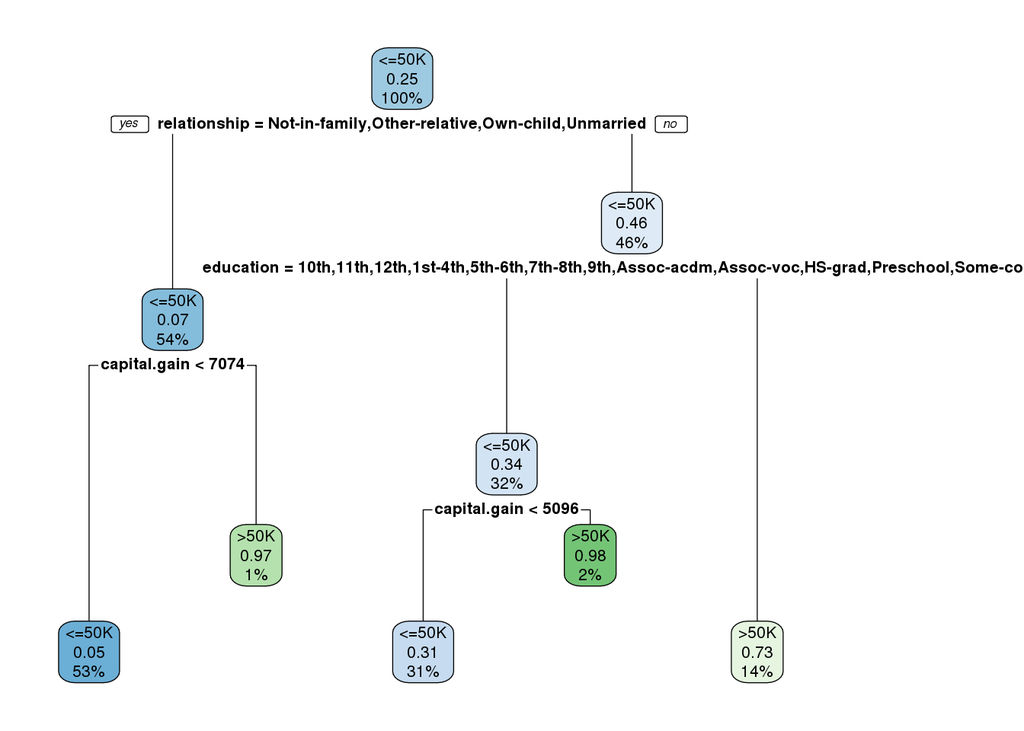

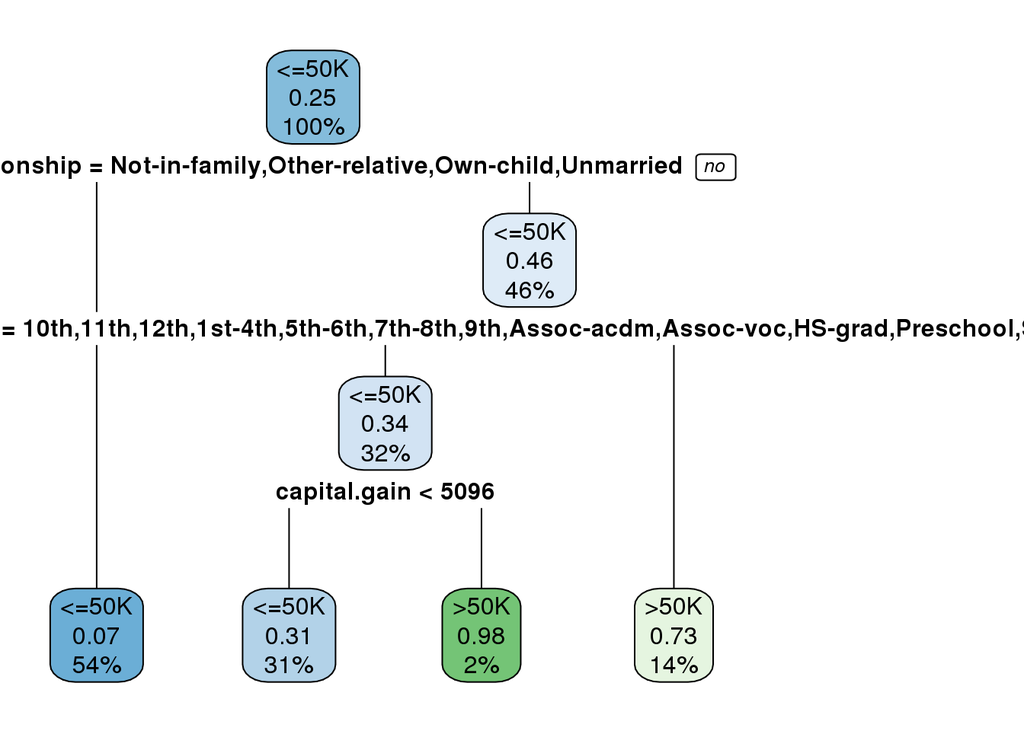

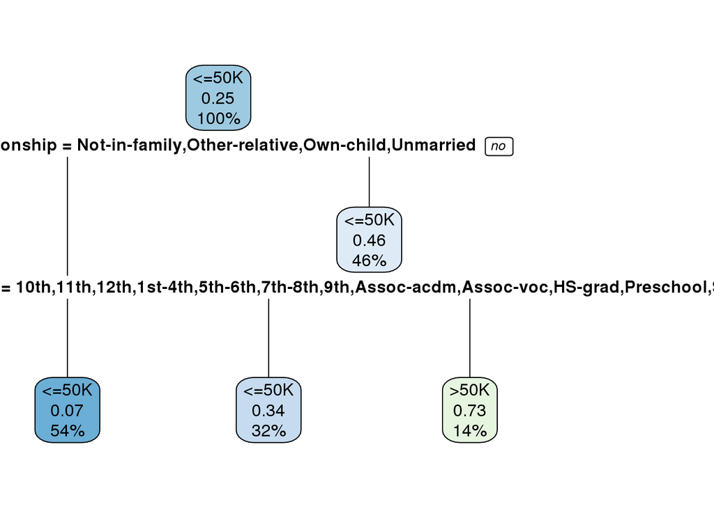

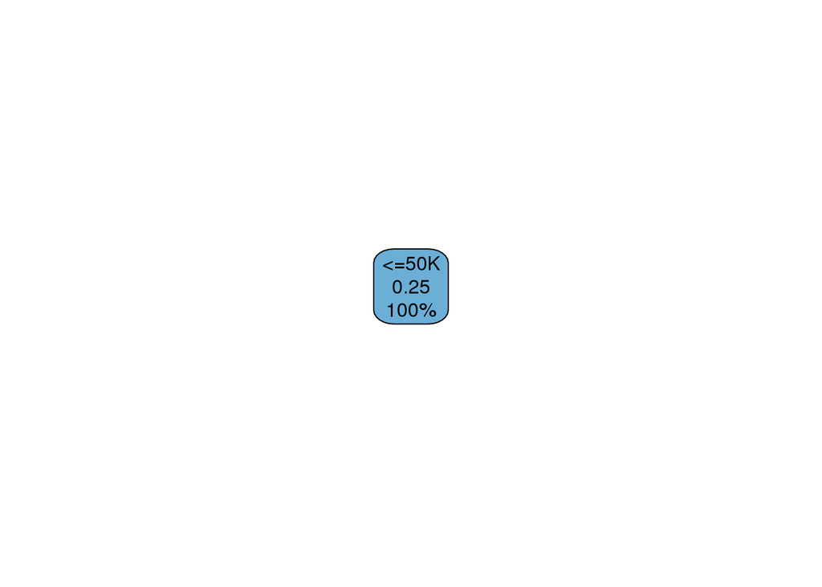

```r
treebuilder2()
```

**Comparing rpart() and randomForest()** While we appreciated the visualization and ability to tune the ‘cp’ parameter allowed to us in the rpart() package, we also wanted consider randomForest, which allows an additional layer of validity because it averages out many less-correlated trees and has proved itself a useful technique.

We had two areas of comparison; first we looked at the overall accuracy, sensitivity, and specificity using the in-sample method. We felt this was somehwat useful in that neither model uses all the data at one time when creating coefficients and estimates–the random forest uses a subset of the data and a subset of the predictors, and the recursive partionining with the gini coefficient uses a subset of the data…

Comparing randomForest and rpart errors calculated in-sample; showing the confusion matrix outputs

```r
mod_Everything <- randomForest(income ~capital.gain+capital.loss+occupation, data = census, importance = TRUE)
randomForest_in_sample <- predict(mod_Everything, data = census, type= "class", split=TRUE)
r<-table(census$income, randomForest_in_sample)

mod_Everything_rpart <- rpart(income ~capital.gain+capital.loss+occupation , data = census)
rpart_in_sample <- predict(mod_Everything_rpart, data = census, type= "class", split=TRUE)
rp<-table(census$income, rpart_in_sample)

r
```

```
##        randomForest_in_sample
##         <=50K  >50K
##   <=50K 22870   198
##   >50K   5478  2172
```

```r
rp
```

```
##        rpart_in_sample
##         <=50K  >50K
##   <=50K 22898   170
##   >50K   5570  2080
```

The confusion matrices can then be used to calculate the in-sample accuracy, overestimation rate, and underestimation rate for each model, which we assembled into a dataframe for easy comparison

```
##     model used               err              sens              spec
## 1 randomForest 0.184777654795234 0.716078431372549 0.991416681116698
## 2        rpart 0.186861123771079 0.728104575163399 0.992630483787064
```

Interestingly, the randomForest model is better overall, but more likely to committ ‘overestimation’ errors where it predicts a higher income than client actually has. We imagine that if our client was a tax specialist, they would prefer to make ‘underestimates’ based on the assumption that most people would rather overpay taxes one year and be grateful for a refund, then underpay and potentially not be able to pay it off.

```r
mod_Everything <- randomForest(income ~capital.gain+capital.loss+occupation, data = c_train, importance = TRUE)
randomForest_out_sample <- predict(mod_Everything, data = c_test, type= "class", split=TRUE)
r<-table(c_test$income, randomForest_out_sample)

mod_Everything_rpart <- rpart(income ~capital.gain+capital.loss+occupation, data = c_train)
rpart_out_sample <- predict(mod_Everything_rpart, data = c_test, type= "class", split=TRUE)
rp<-table(c_test$income, rpart_out_sample)

r
```

```
##        randomForest_out_sample
##         <=50K  >50K
##   <=50K 11365   222
##   >50K   2768  1004
```

```r
rp
```

```
##        rpart_out_sample
##         <=50K  >50K
##   <=50K 11402   185
##   >50K   2792   980
```

```r
err<-(r[1,2]+r[2,1])/(r[1,1]+r[2,1] + r[1,2] +r[2,2])
overest<-(r[1,2]/(r[1,1]+r[2,1] + r[1,2] +r[2,2]))
underest<-(r[2,1]/(r[1,1]+r[2,1] + r[1,2] +r[2,2]))

sens<-(r[2,1]/(r[2,1]+r[2,2]))
spec<-(r[1,1]/(r[1,2]+r[1,1]))

rp_err<-(rp[1,2]+rp[2,1])/(rp[1,1]+rp[2,1] + rp[1,2] +rp[2,2])
rp_overest<-(rp[1,2]/(rp[1,1]+rp[2,1] + rp[1,2] +rp[2,2]))
rp_underest<-(rp[2,1]/(rp[1,1]+rp[2,1] + rp[1,2] +rp[2,2]))

rp_sens<-(rp[2,1]/(rp[2,1]+rp[2,2]))
rp_spec<-(rp[1,1]/(rp[1,2]+rp[1,1]))

df<-data.frame(matrix(, nrow=2, ncol=4))
names(df)<-c("model used", "err", "sens", "spec")
df[1,1:4]<-c("randomForest",err,sens,spec)
df[2,1:4]<-c("rpart",rp_err,rp_sens,rp_spec)

df
```

```
##     model used               err              sens              spec
## 1 randomForest 0.194674132430497 0.733828207847296 0.980840597221024
## 2        rpart  0.19382772315906 0.740190880169671  0.98403383101752
```

[output not shown]